# European COVID-19 Forecast Hub Evaluation Report for SDSC_ISG-TrendModel

2021-10-11

# Forecast visualisation

Forecasts of cases/deaths per week per 100,000. The date of the tab marks the date on which a forecast was made (only the latest forecasts and the previous 4 weeks shown).

## 2021-10-11

### Cases

No forecasts available, possibly because of recent anomalies in the available data.

### Deaths

No forecasts available, possibly because of recent anomalies in the available data.

## 2021-10-04

### Cases

No forecasts available, possibly because of recent anomalies in the available data.

### Deaths

No forecasts available, possibly because of recent anomalies in the available data.

## 2021-09-27

### Cases

No forecasts available, possibly because of recent anomalies in the available data.

### Deaths

No forecasts available, possibly because of recent anomalies in the available data.

## 2021-09-20

### Cases

No forecasts available, possibly because of recent anomalies in the available data.

### Deaths

No forecasts available, possibly because of recent anomalies in the available data.

## Predictive performance

Scores separated by target and forecast horizon.

### Cases

#### 1 week ahead horizon

##### Overall skill

Skill is shown as relative absolute error; weighted interval score is not calculated as the 23 quantile levels required are not being provided by the model.The table shows the skill of the SDSC_ISG-TrendModel model (`Model skill`), the ensemble model (`Ensemble skill`), and the best individual model (`Best skill`).

| Location | Model skill | Ensemble skill | Best skill |
| --- | --- | --- | --- |
| Austria | 0.56 | 0.62 | 0.43 |
| Belgium | 1.08 | 0.91 | 0.83 |
| Bulgaria | 0.5 | 0.62 | 0.35 |
| Croatia | 0.39 | 0.63 | 0.32 |
| Cyprus | 0.68 | 0.83 | 0.68 |
| Czechia | 0.23 | 0.48 | 0.12 |
| Denmark | 0.69 | 0.9 | 0.69 |
| Estonia | 0.61 | 0.7 | 0.4 |
| Finland | 0.77 | 0.87 | 0.77 |
| France | 0.95 | 0.8 | 0.59 |

[output cut: 22 more lines]

##### Skill over time

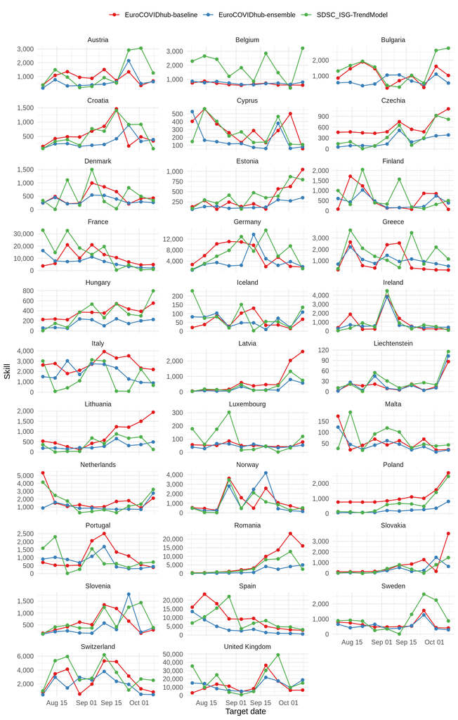

#### 2 weeks ahead horizon

##### Overall skill

Skill is shown as relative absolute error; weighted interval score is not calculated as the 23 quantile levels required are not being provided by the model. Scores are only created for models that were used for forecasts in each of the last 4 weeks, excluding periods during which there were anomalies in the data. At the moment the model does not fulfill that criterion.

##### Skill over time

Skill is shown as weighted interval score is not calculated as the 23 quantile levels required are not being provided by the model. Plots are only created for models that were used for forecasts in each of the last 4 weeks, excluding periods during which there were anomalies in the data. At the moment the model does not fulfills that criterion.

#### 3 weeks ahead horizon

##### Overall skill

Skill is shown as relative absolute error; weighted interval score is not calculated as the 23 quantile levels required are not being provided by the model. Scores are only created for models that were used for forecasts in each of the last 4 weeks, excluding periods during which there were anomalies in the data. At the moment the model does not fulfill that criterion.

##### Skill over time

Skill is shown as weighted interval score is not calculated as the 23 quantile levels required are not being provided by the model. Plots are only created for models that were used for forecasts in each of the last 4 weeks, excluding periods during which there were anomalies in the data. At the moment the model does not fulfills that criterion.

#### 4 weeks ahead horizon

##### Overall skill

Skill is shown as relative absolute error; weighted interval score is not calculated as the 23 quantile levels required are not being provided by the model. Scores are only created for models that were used for forecasts in each of the last 4 weeks, excluding periods during which there were anomalies in the data. At the moment the model does not fulfill that criterion.

##### Skill over time

Skill is shown as weighted interval score is not calculated as the 23 quantile levels required are not being provided by the model. Plots are only created for models that were used for forecasts in each of the last 4 weeks, excluding periods during which there were anomalies in the data. At the moment the model does not fulfills that criterion.

### Deaths

#### 1 week ahead horizon

##### Overall skill

Skill is shown as relative absolute error; weighted interval score is not calculated as the 23 quantile levels required are not being provided by the model.The table shows the skill of the SDSC_ISG-TrendModel model (`Model skill`), the ensemble model (`Ensemble skill`), and the best individual model (`Best skill`).

| Location | Model skill | Ensemble skill | Best skill |
| --- | --- | --- | --- |
| Austria | 0.83 | 0.78 | 0.52 |
| Belgium | 1.24 | 0.86 | 0.39 |
| Bulgaria | 0.81 | 0.63 | 0.31 |
| Croatia | 0.8 | 0.48 | 0.4 |
| Cyprus | 1.13 | 0.73 | 0.71 |
| Czechia | 0.5 | 0.47 | 0.12 |
| Denmark | 1.39 | 0.89 | 0.89 |
| Estonia | 0.91 | 0.71 | 0.43 |
| Finland | 1.25 | 0.82 | 0.56 |
| France | 1.4 | 0.67 | 0.33 |

[output cut: 22 more lines]

##### Skill over time

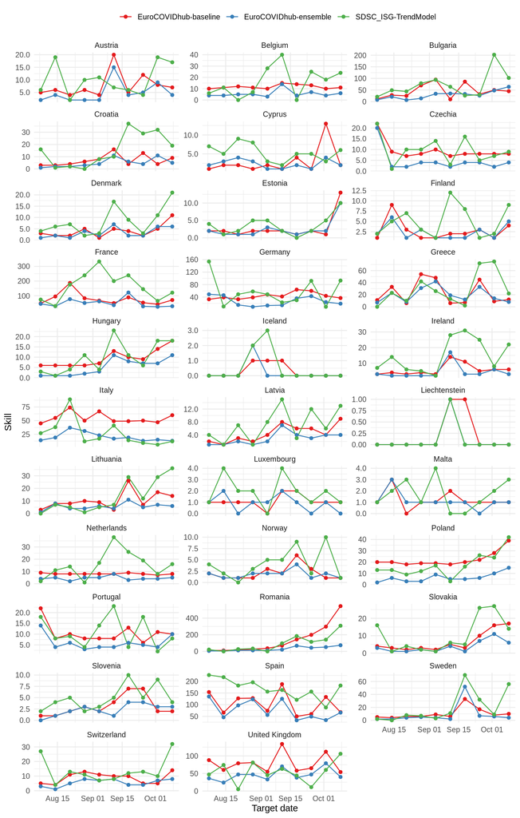

#### 2 weeks ahead horizon

##### Overall skill

Skill is shown as relative absolute error; weighted interval score is not calculated as the 23 quantile levels required are not being provided by the model. Scores are only created for models that were used for forecasts in each of the last 4 weeks, excluding periods during which there were anomalies in the data. At the moment the model does not fulfill that criterion.

##### Skill over time

Skill is shown as weighted interval score is not calculated as the 23 quantile levels required are not being provided by the model. Plots are only created for models that were used for forecasts in each of the last 4 weeks, excluding periods during which there were anomalies in the data. At the moment the model does not fulfills that criterion.

#### 3 weeks ahead horizon

##### Overall skill

Skill is shown as relative absolute error; weighted interval score is not calculated as the 23 quantile levels required are not being provided by the model. Scores are only created for models that were used for forecasts in each of the last 4 weeks, excluding periods during which there were anomalies in the data. At the moment the model does not fulfill that criterion.

##### Skill over time

Skill is shown as weighted interval score is not calculated as the 23 quantile levels required are not being provided by the model. Plots are only created for models that were used for forecasts in each of the last 4 weeks, excluding periods during which there were anomalies in the data. At the moment the model does not fulfills that criterion.

#### 4 weeks ahead horizon

##### Overall skill

Skill is shown as relative absolute error; weighted interval score is not calculated as the 23 quantile levels required are not being provided by the model. Scores are only created for models that were used for forecasts in each of the last 4 weeks, excluding periods during which there were anomalies in the data. At the moment the model does not fulfill that criterion.

##### Skill over time

Skill is shown as weighted interval score is not calculated as the 23 quantile levels required are not being provided by the model. Plots are only created for models that were used for forecasts in each of the last 4 weeks, excluding periods during which there were anomalies in the data. At the moment the model does not fulfills that criterion.

# Forecast calibration

## Overall coverage

No coverage figures shown as now 50%/90% predictive intervals are available.

## PIT histograms

No PIT histogram shown because no predictive quantiles are available.